# Avoir des enfants ou pas : une analyse des facteurs décisifs en France (1991-2019) - Partie 1

Romain Fehri

2024-12-20

# I. Introduction

## I.1. Choix de la variable dépendante

La dynamique démographique joue un rôle central dans le **développement économique** et **hégémonique des nations**. Elle influence non seulement la taille et la structure de la population active, mais également la **viabilité des systèmes sociaux** tels que les retraites, tout en façonnant les **perspectives d’avenir d’une société**. Une population en croissance est souvent perçue comme un moteur d’*innovation*, de *consommation* et de *prospérité économique*, tandis qu’un déclin démographique peut engendrer des défis majeurs, notamment le **vieillissement de la population**, la contraction de la main-d’œuvre et un **pessimisme collectif** quant à l’avenir.

En France, cette problématique prend une acuité particulière. En **2023**, *678 000 enfants* sont nés, marquant un record historique de **faible natalité** depuis *1938*, en dehors des périodes de guerre. Cette baisse, inquiétante par son ampleur et sa persistance, a conduit **Emmanuel Macron** à évoquer la nécessité d’un *«réarmement démographique»*, illustrant l’urgence perçue au plus haut niveau de l’État. Ce débat dépasse les seules questions statistiques: il touche au cœur des **politiques publiques** et des **choix de société**.

Face à cette situation, nous avons décidé d’explorer les causes de ce phénomène en étudiant les *déterminants de la baisse de la natalité en France*. Comprendre ces facteurs est crucial pour anticiper les défis économiques et sociaux de demain, qu’il s’agisse de garantir la pérennité du système de retraite, d’éviter une baisse de la productivité, ou encore de raviver l’**optimisme quant à l’avenir de la nation**.

Dans un premier temps, nous nous sommes penchés sur le ‘taux de natalité’, soit le nombre de naissances rapporté à la population totale. Cependant, nos premières analyses économétriques ont révélé que cette variable est principalement influencée par des *dynamiques démographiques globales*.

C’est pourquoi nous avons orienté notre étude vers le ‘taux de fécondité’, *une mesure plus précise et significative, qui rapporte le nombre de naissances au nombre de femmes en âge de procréer. Ce choix nous permet de mieux cerner les véritables moteurs de la fécondité et d’identifier les **leviers potentiels** pour inverser cette tendance.

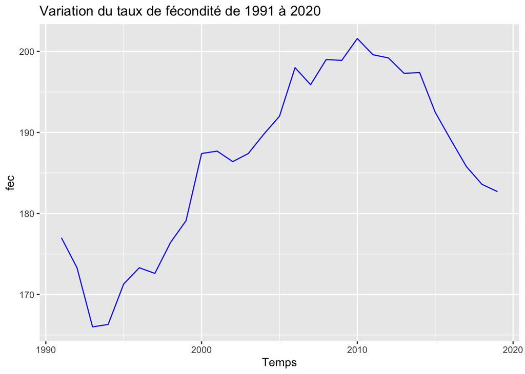

*Nous avons sélectionné la période pour laquelle nous disposions du plus grand nombre de données, soit de 1991 à 2019. Nous avons délibérément exclu l’année 2020, car la crise du COVID-19 a eu un impact significatif sur le taux de fécondité, rendant cette année atypique pour notre analyse.*

## I.2. Les variables explicatives

Nous nous sommes d’abord concertés pour déterminer toutes les varaibles qui pourraient potentiellement expliquer ou être corrélées avec le taux de fécondité, organisées en 5 catégories :

- Facteurs socio-culturels
- Facteurs démographiques et biologiques
- Facteurs économiques et politiques
- Facteurs liés au travail et à l’éducation
- Facteurs individuels et comportementaux

Nous avons réuni **37 variables explicatives**.

Nous avons sélectionné les plus **pertinantes**. Mais nous verrons cela en détail dans la partie 3.

**Finalement, nous avons retenues les variables suivantes** :

- ‘Tx_emploifem’ : Taux d’emmplois des femmes au sens de l’INSEE
- ‘Tx_emploi_flex_fem’ : taux d’emplois précaire (CDD, stage, intérim etc..)
- ‘opi_passé_niv_vie’ : sentiment que, depuis une dizaine d’années, son niveau de vie s’améliore
- ‘bourse’ : évolution du cours des actions du CAC40 en indice base 100, 2015
- ‘opi_insécurité’ : part d’individus (18-24 ans) vivant dans l’inquiétude vis-à-vis de risque d’agression dans la rue
- ‘opi_future_niv_vie’ : opinion sur le niveau de vie futur en France
- ‘opi_inflation’ : opinion sur l’évolution future des prix (positive = hausse des anticipations)
- ‘loyers’ : évolution de l’indice des prix des loyers en indice base 100, 2019
- ‘nuptialite’ : nombre de mariages pour 1000 personnes
- ‘spepro_cadrefemmes’ : part des femmes cadres dans l’emplois total des femmes
- ‘IVG_100’ : nombre d’IVG pour 100 naissances
- ‘études_sup’ : proportion de la population ayant poursuivie des études supérieures au bac

*Sources : INSEE, DREES, OCDE, INED, EUROSTAT, CRÉDOC*

## I.3. Enseignements de nos premières regressions

Dès les premières régressions que nous avons réalisées, deux principaux problèmes sont apparus : la présence de **l’hétéroscédasticité** et de l’**autocorrélation**.

Dans la suite du code, nous avons concentré nos efforts sur la réduction de ces problèmes.

# II. Premier traitement de nos variables explicatives

## II.1. Interpolation linéaire des années (1991 - 2019) et création des variables explicatives décalées `lag`

Nous avons augmenté le nombre d’observations (initialement limité à 29, correspondant aux nombres d’années étudiées) en désagrégeant les données annualisées de la variable temporelle pour générer une séquence trimestrielle couvrant la période 1991-2019.

Les valeurs manquantes des variables numériques ont été imputées à l’aide d’une interpolation linéaire, estimant les données manquantes en se basant sur les observations existantes. Cette étape a permis d’obtenir un jeu de données uniforme et cohérent sur l’ensemble de la période analysée, sans altérer la relation linéaire inhérente aux données.

Ensuite, nous avons utilisé une fonction `lag`pour créer des variables décalées, en considérant que les naissances à une période donnée *(t)* sont influencées par les décisions individuelles et par leur propre niveau à la période précédente *(t-1)*. Cette hypothèse repose principalement sur le fait qu’une gestation dure environ **9 mois**, ce qui implique un effet différé des facteurs explicatifs d’une année sur les naissances de l’année suivante.

```r
## Interpolation trimestrielle et création des variables décalées (lags)
data_clean <- data %>%
  complete(Temps = seq(min(Temps), max(Temps), by = 0.25)) %>%
  mutate(across(all_of(numeric_cols),
                ~ approx(Temps[!is.na(.)], .[!is.na(.)], xout = Temps)$y)) %>%
  arrange(Temps) %>%
  mutate(across(setdiff(numeric_cols, "fec"), ~ lag(., n = 4), .names = "lag_{col}")) %>%
  drop_na(starts_with("lag_"))

data_work <- data_clean %>%
  select(Temps, fec, starts_with("lag_"))
```

## II.2. Stationarisation de la serie chronologique

Nous avons transformé notre série chronologique en une série **stationnaire** via les méthodes de *détrendisation* et *différenciation*. Cette étape stabilise les propriétés statistiques (variance, moyenne, covariance), réduit les risques l’hétéroscédasticité et élimine les biais liés aux tendances temporelles. Elle permet de mieux cibler les fluctuations à court terme, souvent plus pertinentes, et constitue une condition nécessaire pour appliquer des méthodes robustes comme *GLS*, *ARIMA* ou encore les ajustements de *Newey-West*.

## Visualisation de la tendance

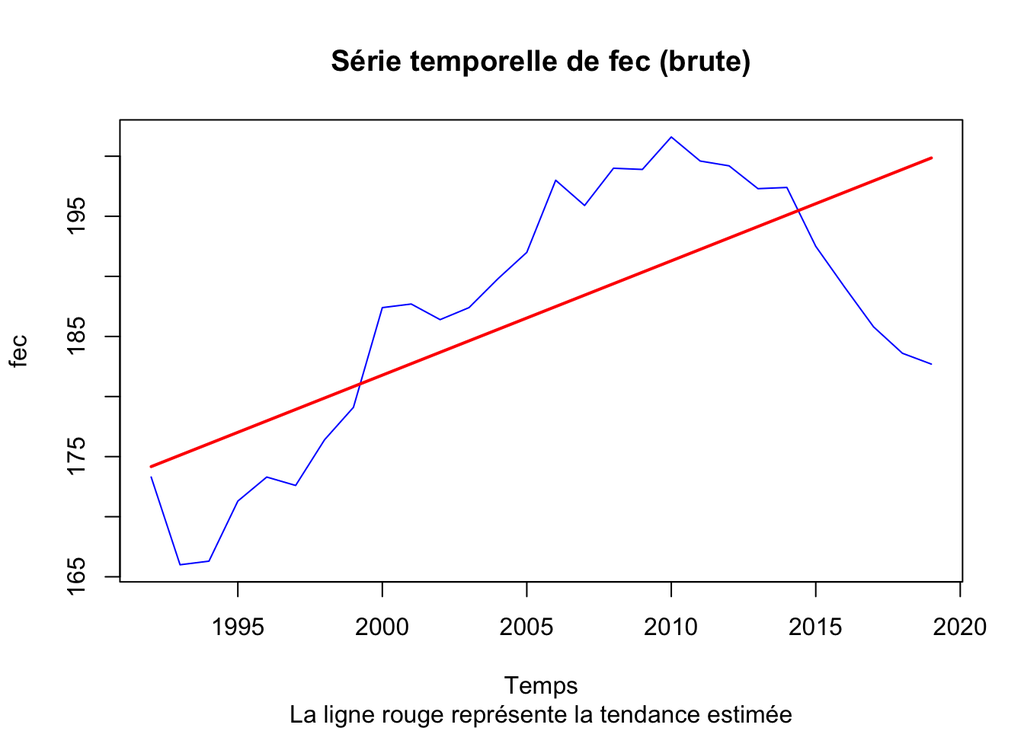

```r
# 3. Visualiser la variable fec dans le Temps
plot(data_work$Temps, data_work$fec, type = "l",
     main = "Série temporelle de fec (brute)",
     xlab = "Temps", ylab = "fec", col = "blue")

# 4. Estimation de la tendance linéaire
modele_tendance <- lm(fec ~ Temps, data = data_work)
tendance_estimee <- fitted(modele_tendance)

# Ajout de la tendance sur le graphique
lines(data_work$Temps, tendance_estimee, col = "red", lwd = 2)
title(sub = "La ligne rouge représente la tendance estimée")
```

```r
# 5. Test ADF sur la série brute fec
cat("\n--- Test ADF sur la série brute (fec) ---\n")
```

```
##
## --- Test ADF sur la série brute (fec) ---
```

```r
adf_result_fec <- adf.test(data_work$fec, alternative = "stationary")
print(adf_result_fec)
```

```
##
##  Augmented Dickey-Fuller Test
##
## data:  data_work$fec
## Dickey-Fuller = 0.67502, Lag order = 4, p-value = 0.99
## alternative hypothesis: stationary
```

```r
if (adf_result_fec$p.value < 0.05) {
  cat("\nInterprétation : La série brute 'fec' est stationnaire (H₀ rejetée).\n")
} else {
  cat("\nInterprétation : La série brute 'fec' n'est pas stationnaire (H₀ non rejetée).\n")
}
```

```
##
## Interprétation : La série brute 'fec' n'est pas stationnaire (H₀ non rejetée).
```

```r
#  Dé-trending de la série brute
data_work$fec_detrend <- data_work$fec - tendance_estimee

#  Différenciation directe de la série brute
data_work$fec_diff <- c(NA, diff(data_work$fec))

# Test ADF sur la série détrendue
cat("\n--- Test ADF sur la série détrendue (fec_detrend) ---\n")
```

```
##
## --- Test ADF sur la série détrendue (fec_detrend) ---
```

```r
adf_result_detrend <- adf.test(data_work$fec_detrend, alternative = "stationary")
print(adf_result_detrend)
```

```
##
##  Augmented Dickey-Fuller Test
##
## data:  data_work$fec_detrend
## Dickey-Fuller = 0.67502, Lag order = 4, p-value = 0.99
## alternative hypothesis: stationary
```

```r
# Test ADF sur la série brute différenciée
cat("\n--- Test ADF sur la série brute différenciée (fec_diff) ---\n")
```

```
##
## --- Test ADF sur la série brute différenciée (fec_diff) ---
```

```r
adf_result_fec_diff <- adf.test(na.omit(data_work$fec_diff), alternative = "stationary")
print(adf_result_fec_diff)
```

```
##
##  Augmented Dickey-Fuller Test
##
## data:  na.omit(data_work$fec_diff)
## Dickey-Fuller = -3.6352, Lag order = 4, p-value = 0.03333
## alternative hypothesis: stationary
```

**Cependant, interpréter ces variations en termes absolus a peu de sens d’un point de vue économique**. C’est pourquoi nous privilégions une approche en termes de variations relatives, autrement dit, le taux de croissance du taux de fécondité d’une année à l’autre.

La transformation de notre variable dépendante en taux de croissance présente deux principaux avantages :

- Une interprétation plus intuitive : elle permet une lecture en termes de semi-élasticité, facilitant ainsi l’analyse.
- Stationnarisation de la série : cette transformation rend la série stationnaire, ce qui la rend adaptée à l’utilisation de solutions spécifiques pour traiter les problèmes d’autocorrélation et d’hétéroscédasticité.

```r
# 9. Créer data_work_trend avec les variables nécessaires
# Inclure toutes les variables (Temps, fec, fec_detrend, fec_diff et création de fec_diff_relative)
data_work_trend <- data.frame(
  Temps = data_work$Temps,
  fec = data_work$fec,
  fec_detrend = data_work$fec_detrend,
  fec_diff = data_work$fec_diff
) %>%
  mutate(fec_var_relative = fec_diff / fec) # Ajouter fec_diff_relative
```

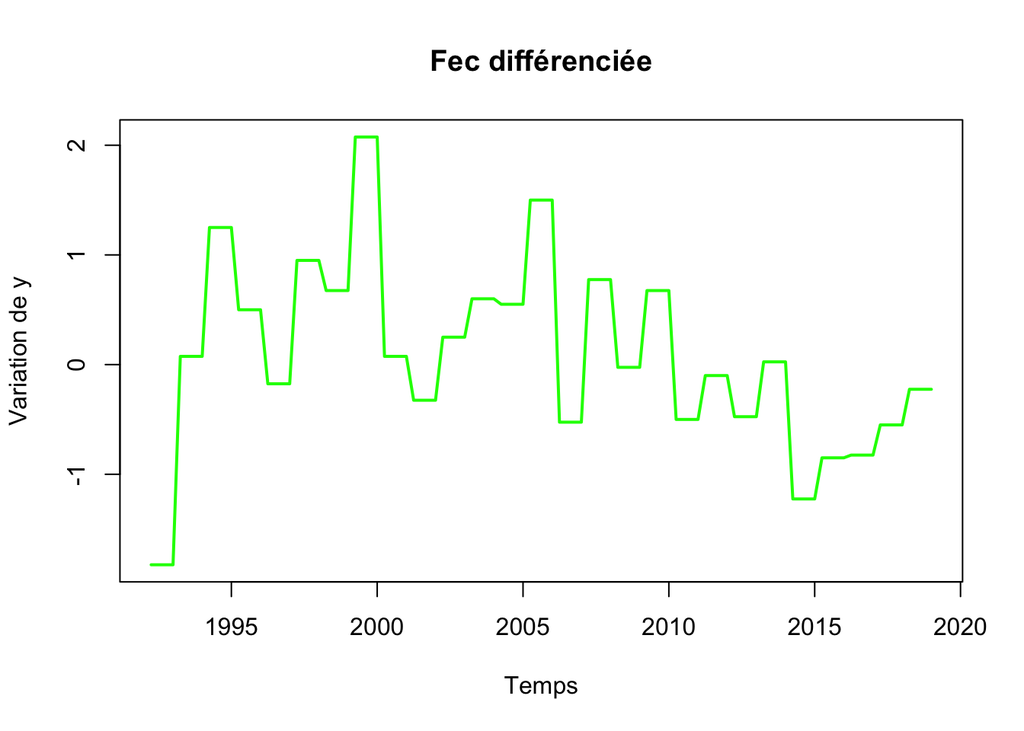

```r
# Superposer fec_detrend_diff et fec_diff sur un seul graphique avec un label en bas
plot(data_work_trend$Temps, data_work_trend$fec_diff, type = "l", col = "green",
     main = "Fec différenciée",
     xlab = "Temps", ylab = "Variation de y", lwd = 2)
```

Ainsi, nous allons pouvoir développer un modèle visant à expliquer les variations annuelles du taux de fécondité, tout en excluant la part de cette évolution directement attribuable à la tendance de long terme.

Cependant, une question demeure : **quelle proportion du taux de fécondité peut être expliquée par des phénomènes purement tendanciels, et quelle part reste inexpliquée ?**

```r
# 1. Modèle : notre variable Fec expliquée par la tendance ?
modele_fec_vs_detrend <- lm(fec ~ fec_detrend, data = data_work_trend)
r2_fec_vs_detrend <- summary(modele_fec_vs_detrend)$r.squared
cat(sprintf("- Fec expliquée par Fec_detrend : %.2f%%\n", r2_fec_vs_detrend * 100))
```

```
## - Fec expliquée par Fec_detrend : 50.88%
```

- Les politiques publiques (*allocations familiales, congés parentaux*),
- Les fluctuations économiques (*chômage, pouvoir d’achat*),
- Ou encore des événements exceptionnels (*crises, changements démographiques régionaux*).

L’analyse de ces facteurs permet de mieux cerner les **leviers** qui influence l’évolution du taux de fécondité en France.

## II.3. Création d’un jeu de données sans les outliers (avant première regression)

Cette démarche présente plusieurs avantages :  
- Elle réduit l’**influence disproportionnée des valeurs extrêmes** sur les coefficients estimés.  
- Elle améliore la fiabilité des résultats en respectant mieux les **hypothèses des régressions OLS**, notamment l’**homoscédasticité** et la **normalité des résidus**.

Cependant, cette méthode comporte également un inconvénient notable :  
- Elle réduit la taille de l’échantillon en supprimant des observations, ce qui peut entraîner une **perte d’information utile** dans certains cas.

En dépit de cette limitation, nous avons jugé que l’impact positif de cette étape sur la robustesse des résultats justifiait son adoption dans notre analyse.

```r
# Renommer 'fec_diff_relative' en 'fec'
data_work_trend <- data_work_trend %>%
  rename(fec = fec_var_relative)

# 1. Modèle standardisé (centré et réduit)
data_model_standardized <- data_work_trend %>%
  mutate(across(starts_with("lag_"), ~ scale(.)))

model_standardized <- lm(fec ~ . - Temps, data = data_model_standardized)
# Étape 2 : Calculer les résidus bruts et standardisés
residuals_standardized_df <- data.frame(
  Index = seq_len(nrow(data_work_trend)),
  Resid = residuals(model_standardized),      # Résidus bruts
  Std_Resid = rstandard(model_standardized),  # Résidus standardisés
  Temps = data_work_trend$Temps,
  fec = data_work_trend$fec
)
```

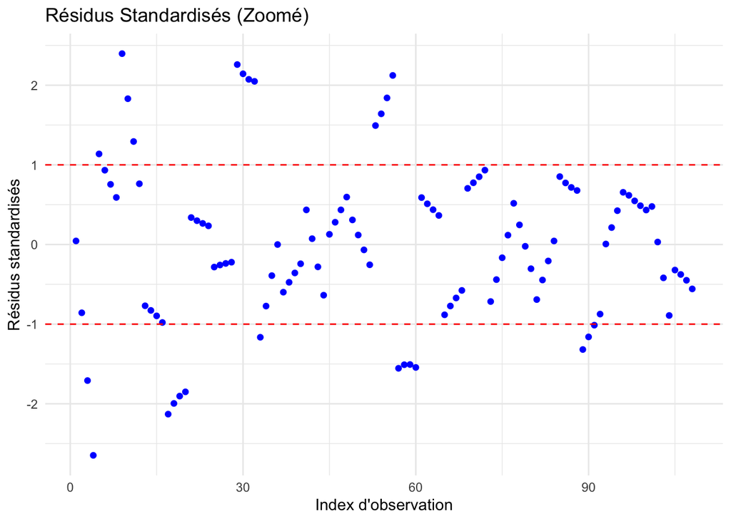

```r
threshold_zoom <- 3
plot_residus_standardises <- ggplot(residuals_standardized_df %>% filter(abs(Std_Resid) <= threshold_zoom)) +
  geom_point(aes(x = Index, y = Std_Resid), color = "blue") +
  geom_hline(yintercept = c(-1, 1), color = "red", linetype = "dashed") +
  labs(
    title = "Résidus Standardisés (Zoomé)",
    x = "Index d'observation",
    y = "Résidus standardisés"
  ) +
  theme_minimal()

print(plot_residus_standardises)
```

```r
# Étape 5 : Identifier les outliers
threshold <-3   # Seuil pour identifier les outliers
outliers_standardized_df <- residuals_standardized_df %>%
  filter(abs(Std_Resid) > threshold)

cat("\n### Résumé des outliers identifiés ###\n")
```

```
##
## ### Résumé des outliers identifiés ###
```

```r
print(outliers_standardized_df)
```

```
## [1] Index     Resid     Std_Resid Temps     fec
## <0 rows> (or 0-length row.names)
```

Au total, **Aucune observations ont été supprimées.**